# Twitter Analysis - Biden and Trump

2024-11-09

This projects uses statistical learning and data science methods to analyze a set of tweets from Biden and Trump.

## Libraries

```r
library(tidyverse)
```

```r
library(tidytext)
library(lubridate)
library(ggwordcloud)
library(caret)
```

## Load Data

```r
#Trump Tweets
trump <- read_csv("/Users/kayleywatson/Desktop/Stat 218/realdonaldtrump.csv")
#Biden Tweets
biden <- read_csv("/Users/kayleywatson/Desktop/Stat 218/JoeBidenTweets.csv")
```

Data sourced from kaggle.

- https://www.kaggle.com/datasets/austinreese/trump-tweets
- https://www.kaggle.com/datasets/rohanrao/joe-biden-tweets

We chose to explore differences tweets posted by the accounts of two presidents: Donald Trump and Joe Biden. We found two data sets, one for each president. Biden’s tweets ranged from October 24th, 2007 to November 1st 2020. Trump’s tweets ranged from May 4th, 2009 to June 17th, 2020. Biden tweeted a total of 6,064 times while Trump tweeted 43,352 times. This means that there is more data from Trump’s account than Biden’s.

Because each of these tweets has multiple words in it, we needed to use some method to decrease the amount of data we were using to make the run time more manageable. Originally, it was supposed to take about 8 hours using the entirety of both data sets, so instead we decided to focus on a specific window of time that we thought would yield interesting results. We isolated a period of four months from each of the candidates: January to April of 2020. This period was after both presidents had announced they intended to run for president and it also included the beginning of the Covid-19 pandemic.

## Clean and Merge Data

```r
colnames(trump)
```

```
## [1] "id"        "link"      "content"   "date"      "retweets"  "favorites"
## [7] "mentions"  "hashtags"
```

```r
colnames(biden)
```

```
## [1] "id"        "timestamp" "url"       "tweet"     "replies"   "retweets"
## [7] "quotes"    "likes"
```

```r
#Trump data
trump <- trump %>%
  select(3, 4)
names(trump)[1] <- "tweet"

new_order = c("date", "tweet")
trump <- trump[, new_order]

trump <- trump %>%
  mutate(author = "trump") %>%
  filter(year(date) == 2020) %>%
  filter(month(date) == sequence(1:4)) %>%
  mutate(id = row_number())
#Biden data
biden <- biden %>%
  select(2, 4)

names(biden)[1] <- "date"

biden <- biden %>%
  mutate(author = "biden") %>%
  filter(year(date) == 2020) %>%
  filter(month(date) == sequence(1:4)) %>%
  mutate(id = row_number() + 386)
#Check ids for the two datasets
any(trump$id %in% biden$id)
```

```
## [1] FALSE
```

```r
#bind datasets into one
tweets <- rbind(trump, biden) %>%
  select(-1)

#get rid of scraped in url
tweets <- tweets %>%
  mutate(tweet = gsub("https://.*", "", tweet)) %>%
  mutate(tweet = gsub("pic.twitter.com*", "", tweet))

#check for duplicate ids
anyDuplicated(tweets$id)
```

```
## [1] 0
```

We looked at our data and realized that there were some issues. The scraped in data included the URLs of the tweets, which could have affected the ending word of each tweet and made creating our document-feature matrix a lot messier. We also found that there were links to images attached to some tweets, mainly Trump’s, which is interesting, but not what we are testing. Because of this, we needed to remove the links since they could have biased our model.

## Create Document-Feature Matrix

```r
#remove stop words
tweets_clean <- tweets %>%
  unnest_tokens(input = "tweet",
                output = "word",
                token = "words") %>%
  filter(!(word %in% stop_words$word))


colnames(tweets_clean)
```

```
## [1] "author" "id"     "word"
```

```r
names(tweets_clean)[1] <- "tweeter"
names(tweets_clean)[2] <- "numerical_code"

tweets_clean_wc <- tweets_clean %>%
  count(numerical_code, tweeter, word, name = "n")

dfm <- tweets_clean_wc %>%
  ungroup() %>%
  pivot_wider(
    id_cols = c("numerical_code", "tweeter"),
    names_from = "word",
    values_from = "n",
    values_fn = sum,
    values_fill = list(n = 0)
  )
```

We created a document-feature matrix and got rid of stop words, since they add extra unnessesary information and would not give us any compelling examples of unique language usage.

## Explore with Unsupervised Learning

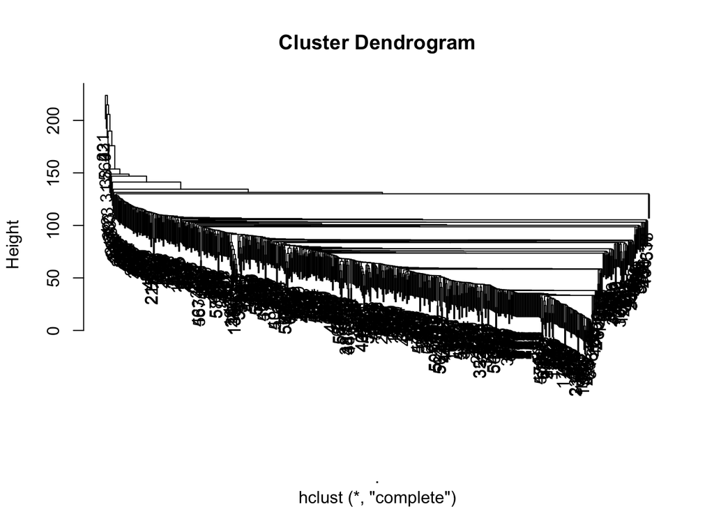

```r
lost_tweets <- setdiff(tweets$id, dfm$numerical_code)

#same rows as dfm
tweets_lost_re <- tweets |>
  filter(!id %in% lost_tweets)

dfm_hclust <- dfm %>%
  select(-numerical_code, -tweeter, -word) %>%
  scale() %>%
  dist() %>%
  hclust()

  plot(dfm_hclust)
```

```r
  #number of clusters
dfm_clusts <- cutree(dfm_hclust, k = 50)

#checking groupings of 1 as outliers
outlier_clusters <- names(table(dfm_clusts)[table(dfm_clusts) == 1])

#finding rows that are outliers
outliers <- dfm[dfm_clusts %in% outlier_clusters, ]

#printing outlier rows to check
outlier_tweets <- tweets_lost_re |>
  filter(id %in% outliers$numerical_code)

#language tweets 32 only a bit of spanish
langauge_tweets <- c(587, 35, 18, 9, 4, 5, 2)
```

In order to further understand the data and outliers, we used a dendrogram to understand how the data groups together, etc. From the dendrogram, we mapped the outlier tweet row numbers to the main tweets data set in order to see what the tweets looked like and see if they were fit to include in the dataset or if they merited special treatment of some sort. After looking through the dendrogram outliers, we noticed some tweets were considered far in distance from others as a result of the inclusion of URLs or usernames. The ones that were the most concerning were those in other languages. We noticed 7 tweets that had Spanish, Hebrew, Sanskrit, and Arabic. Because our model is mostly in English, we decided to remove words that were in other languages and special characters from the word count data sets, as special characters and other languages are data that don’t seem relevant to the goals of this project.

## Create Document-Feature Matrix with Only Words Above a Certain Count

```r
song_word_counts <- dfm %>%
  select_if(is.numeric) %>%
  colSums()

X <- 7

#Take my song_word_counts vector and only return elements which have a value greater than X.
good_words <- names(song_word_counts[which(song_word_counts > X)])

dfm_2 <- dfm %>%
  select(all_of(good_words))
```

We then decided to create a new document feature matrix that only included words that occurred more than 7 times in all the tweets we selected (January to April 2020) from the original 2 sets. By doing this, it got rid of common words that did not give us any meaningful information or show differences between the two tweeters. We choose 7 because it was a nice balance between highlighting words used repeatedly and words that did not mean anything. It also gave us 164 common words between the two authors to build our further models and visual off of.

# Preliminary Random Forest

```r
library(caret)

names(dfm_2)[1] <-"id"

tweets_join <- dfm_2 %>%
  left_join(tweets, dfm_2, by = "id") %>%
  select(-99) #delete column with full tweets


tweet_rf_data <- tweets_join %>%
  mutate(author = factor(tweets_join$author)) %>% #categorical variable
  select(-id) %>%
  na.omit()

prelim_tweet_rf <- train(author ~ .,
                 data = tweet_rf_data,
                 method = "ranger",
                 importance = "impurity")

confusionMatrix(prelim_tweet_rf)
```

```
## Bootstrapped (25 reps) Confusion Matrix
##
## (entries are percentual average cell counts across resamples)
##
##           Reference
## Prediction biden trump
##      biden  30.3   5.8
##      trump  10.5  53.4
##
##  Accuracy (average) : 0.8369
```

```r
#variable importance
varImp(prelim_tweet_rf)
```

```
## ranger variable importance
##
##   only 20 most important variables shown (out of 784)
##
##           Overall
## donald     100.00
## president   35.13
## crisis      33.82
## demdebate   26.92
## trump       26.64
## ensure      23.96
## nation      23.43
## folks       21.73
## middle      19.31
## beat        18.91
## day         16.70
## nevada      16.26
## act         15.74
## bring       15.51
## news        15.11
## `let’s`     15.07
## support     14.99
## country     14.20
## campaign    13.65
## public      13.05
```

After running a preliminary random forest, one interesting pair of words were “Donald,” and “Trump”. Because these are the first and last names of one of the authors, it is important to make sure they are not biasing the results. If the two candidates signed their tweets with their names, that would be telling the model exactly what to predict, which is essentially “cheating”. After further exploration, we found that Biden was actually the one naming Trump as a topic of interest in his tweets. This means that the two words “Donald” and “Trump” are significant and important for the model and should be kept in as useful indicators. The word “Biden” only popped up a few times and was used fairly equally by both candidates and not to sign off a tweet, so it does not bias the data and can stay in the data set.

## PCA and Random Forest

```r
#PCA
pca_tweets <- tweet_rf_data %>%
  select(-author, -tweet) %>%
  prcomp()

round((pca_tweets$sdev)^2, 3)
```

```
##   [1] 0.234 0.148 0.135 0.129 0.115 0.112 0.097 0.093 0.089 0.089 0.081 0.077
##  [13] 0.072 0.070 0.062 0.060 0.056 0.055 0.053 0.050 0.049 0.048 0.047 0.045
##  [25] 0.044 0.044 0.043 0.041 0.040 0.040 0.039 0.038 0.038 0.037 0.036 0.036
##  [37] 0.035 0.034 0.033 0.033 0.032 0.032 0.032 0.031 0.030 0.030 0.029 0.029
##  [49] 0.028 0.028 0.027 0.026 0.026 0.026 0.025 0.025 0.024 0.024 0.024 0.023
##  [61] 0.023 0.023 0.022 0.022 0.022 0.021 0.021 0.021 0.021 0.020 0.020 0.019
##  [73] 0.019 0.019 0.018 0.018 0.018 0.018 0.018 0.017 0.017 0.017 0.016 0.016
##  [85] 0.016 0.016 0.015 0.015 0.015 0.015 0.015 0.014 0.014 0.014 0.014 0.014
##  [97] 0.013 0.013 0.013 0.013 0.012 0.012 0.012 0.012 0.012 0.011 0.011 0.011
## [109] 0.011 0.011 0.010 0.010 0.010 0.010 0.010 0.010 0.009 0.009 0.009 0.009
## [121] 0.009 0.009 0.008 0.008 0.008 0.008 0.008 0.008 0.007 0.007 0.007 0.007
## [133] 0.007 0.007 0.007 0.007 0.006 0.006 0.006 0.006 0.006 0.005 0.005 0.005
## [145] 0.005 0.005 0.005 0.005 0.004 0.004 0.004 0.004 0.004 0.004 0.004 0.003
## [157] 0.003 0.002 0.002 0.002 0.001 0.001
```

```r
# adding PCAs to the dataframe in order to shorten runtime of the
#random Forest --> 20 (rows w more than 5% varience explained)

tweet_rf_final <- tweet_rf_data |>
  mutate(PC1 = pca_tweets$x[,1],
         PC2 = pca_tweets$x[,2],
         PC3 = pca_tweets$x[,3],
         PC4 = pca_tweets$x[,4],
         PC5 = pca_tweets$x[,5],
         PC6 = pca_tweets$x[,6],
         PC7 = pca_tweets$x[,7],
         PC8 = pca_tweets$x[,8],
         PC9 = pca_tweets$x[,9],
         PC10 = pca_tweets$x[,10],
         PC11 = pca_tweets$x[,11],
         PC12 = pca_tweets$x[,12])


boot632_validation <- trainControl(
  method = "boot632",
  number = 50,)
set.seed(10)
tweet_rf1 <- train(author ~ PC1 + PC2 + PC3 + PC4 + PC5 + PC6 + PC7 + PC8 + PC9 + PC10 + PC11 + PC12,
                  data = tweet_rf_final,
                  method = "ranger",
                  importance = "impurity",
                  tuneGrid = data.frame(expand.grid(mtry = c(2), splitrule = c("gini"), min.node.size = 7)),
                  trControl = boot632_validation)

confusionMatrix(tweet_rf1)
```

```
## Bootstrapped (50 reps) Confusion Matrix
##
## (entries are percentual average cell counts across resamples)
##
##           Reference
## Prediction biden trump
##      biden  30.1  10.8
##      trump  11.1  48.0
##
##  Accuracy (average) : 0.7813
```

```r
tweet_rf2 <- train(author ~ .,
                 data = tweet_rf_data,
                 method = "ranger",
                 importance = "impurity")
confusionMatrix(tweet_rf2)
```

```
## Bootstrapped (25 reps) Confusion Matrix
##
## (entries are percentual average cell counts across resamples)
##
##           Reference
## Prediction biden trump
##      biden  29.7   5.8
##      trump  11.2  53.3
##
##  Accuracy (average) : 0.8299
```

```r
#variable importance
varImp(tweet_rf1)
```

```
## ranger variable importance
##
##       Overall
## PC1  100.0000
## PC5   45.6385
## PC6   32.1937
## PC2   31.4335
## PC3   24.9136
## PC4   24.3481
## PC9   13.8924
## PC11  10.1768
## PC12   5.1219
## PC10   3.0076
## PC8    0.7634
## PC7    0.0000
```

```r
varImp(tweet_rf2)
```

```
## ranger variable importance
##
##   only 20 most important variables shown (out of 784)
##
##           Overall
## donald     100.00
## president   37.15
## crisis      36.01
## trump       35.98
## demdebate   29.31
## nation      28.65
## ensure      25.23
## folks       22.77
## day         19.77
## middle      19.21
## bring       18.00
## beat        17.62
## support     16.80
## nevada      16.75
## act         15.89
## news        15.35
## campaign    15.20
## country     14.81
## `let’s`     14.50
## pay         13.38
```

Because tweets rf data contains 164 variables, we decided to use Principal Component Analysis in order to limit the number of variables going into the model without losing too much of the data’s variance. We used the first 12 principal components in the model in order to speed up the run time of the model for tuning and testing.

We decided to use a random forest model to classify whether a tweet was a Trump or Biden Tweet, because decision trees model how word choice, sentences, and tweets are constructed. We choose a random forest over a tree model, since random forests tend to perform better than trees. We chose to use only 12 of the principal components, since accuracy went down when more were used. We used accuracy as the principal metric to evaluate how good the model performed, since the model had relatively balanced classes. Additionally, we used an mtry of 2, splitrule of gini, and a min node size of of 7, since this combination of parameters led to the highest accuracy after utilizing a variety of values in the tune grid. Finally, we used .63 bootstrapping to validate the model and ensure that it generalizes well to other tweet data. The data generated in the knitted html may differ slightly due to change in seed.

```r
#importance of each PC 10x1
#matricx of PCS 10xn
#word count vector : nX1
matrix_pc <- pca_tweets$rotation[, 1:12]

component_importance <- c(
  PC1   = 100.0000000,
  PC5   = 45.6384630,
  PC6   = 32.1936934,
  PC2   = 31.4335335,
  PC3   = 24.9136014,
  PC4   = 24.3480730,
  PC9   = 13.8923525,
  PC11 = 10.1768336,
  PC12 = 5.1219175,
  PC10 = 3.0075727,
  PC8   = 0.7633637,
  PC7   = 0.0000000
  )



word_importance <- rowSums(matrix_pc * component_importance[1:12])

word_importance <- data.frame(word_importance)

shift <- -1 * min(word_importance$word_importance)

word_importance <- word_importance |>
  mutate(word_importance = word_importance + shift)
print(word_importance) %>%
  arrange(-word_importance) %>%
  head(25)
```

```
##                word_importance
## military              94.51280
## quickly               84.52803
## world                 84.67121
## hampshire             85.49717
## loves                 86.24433
## job                   94.27096
## country                0.00000
## foxnews               84.46336
## it’s                  88.25389
## president             65.91287
## iran                  86.44911
## war                   84.15524
## americans             84.71886
## people                65.45565
## time                 101.14085
## don’t                 86.37408
## united                84.07387
## house                103.80299
## that’s                82.91462
## trump                100.81899
## white                 98.79300
## party                 82.60410
## republican            87.03266
## democrats             78.88924
## economy              105.55517
## hard                  82.05289
## hoax                  85.71469
## impeachment           85.46310
## money                 84.14385
## real                  85.29021
## usa                   87.08160
## american              53.49848
## congress              84.21312
## dems                  84.46573
## vote                  86.68496
## wrong                 85.87358
## day                  156.23102
## happy                 87.31894
## national              86.13629
```

[output cut: 108 more lines]

```
## chip                  83.92654
## soul                  90.45836
## restore               87.53654
## ensure                65.89123
## folks                 81.75270
## middle                82.50332
## moment                83.80725
## climate               87.99804
## bring                 83.52484
## demdebate             80.41330
## plan                  84.05124
## voice                 84.44911
## public                84.11991
## let’s                 85.47579
## lead                  84.90834
```

```
##             word_importance
## day               156.23102
## economy           105.55517
## news              104.96945
## house             103.80299
## time              101.14085
## trump             100.81899
## white              98.79300
## nation             96.05828
## election           95.78648
## mike               95.23718
## donald             94.86001
## strong             94.65740
## border             94.54688
## military           94.51280
## job                94.27096
## crisis             94.24002
## conference         93.26144
## america            93.03231
## fake               92.86465
## chance             90.78085
## soul               90.45836
## 5                  90.42244
## nevada             90.21011
## i’m                90.10986
## endorsement        89.98657
```

To extract the importance of each word to the principal component random forest model, we extracted how important each word was to each component. From there, we multiplied the two to extract how important each word is in the model. Unfortunately, this only extracts how important each word is for the model overall rather than for each class.

## Visualization (Comparison Cloud)

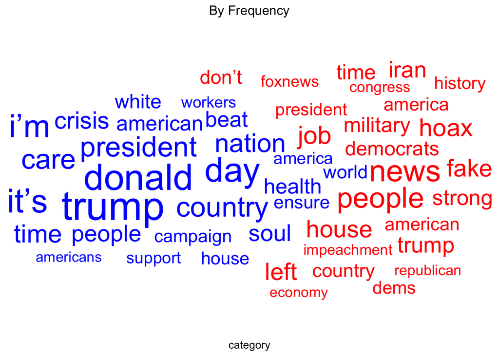

```r
cloud_df <- tweets_clean_wc %>%
  select(-1) %>%
  filter(!grepl("[^A-Za-z0-9[:punct:]\\s]", word)) %>%
  group_by(word, tweeter) %>%  # Group by word and category
  summarize(n = sum(n), .groups = "drop") %>%
  na.omit()

names(cloud_df)[2] <- "category"
names(cloud_df)[4] <- "freq"
#Plot based on author and frequency
top_words_df1 <- cloud_df %>%
  group_by(category) %>%
  arrange(desc(n)) %>%
  slice_head(n = 25) %>%
  ungroup()

set.seed(42)
ggplot(
  top_words_df1,
  aes(
    label = word, size = n,
    x = category,
    color = category
  )
) +
  geom_text_wordcloud_area() +
  scale_size_area(max_size = 30) +
  scale_color_manual(values = c(
    "trump" = "red",
    "biden" = "blue"
  )) +
  scale_x_discrete(breaks = NULL) +
  theme_minimal() +
  labs(title = "By Frequency") +
  theme(plot.title = element_text(hjust = 0.5))
```

```r
#Plot based on frequency weighted by importance
cloud_mag <- cloud_df %>%
  mutate(imp_val = word_importance$word_importance*n)
top_words_df2 <- cloud_mag %>%
  group_by(category) %>%
  arrange(desc(imp_val)) %>%
  slice_head(n = 25) %>%
  ungroup()

cloud_mag %>%
  group_by(category) %>%
  filter(category == "biden") %>%
  arrange(desc(imp_val)) %>%
  head(10)
```

```
## # A tibble: 10 × 4
## # Groups:   category [1]
##    word      category     n imp_val
##    <chr>     <chr>    <int>   <dbl>
##  1 donald    biden       64   5499.
##  2 president biden       53   4677.
##  3 american  biden       27   4218.
##  4 trump     biden       62   4058.
##  5 country   biden       37   3109.
##  6 day       biden       31   2638.
##  7 people    biden       27   2389.
##  8 nation    biden       28   2358.
##  9 campaign  biden       22   2113.
## 10 care      biden       23   2013.
```

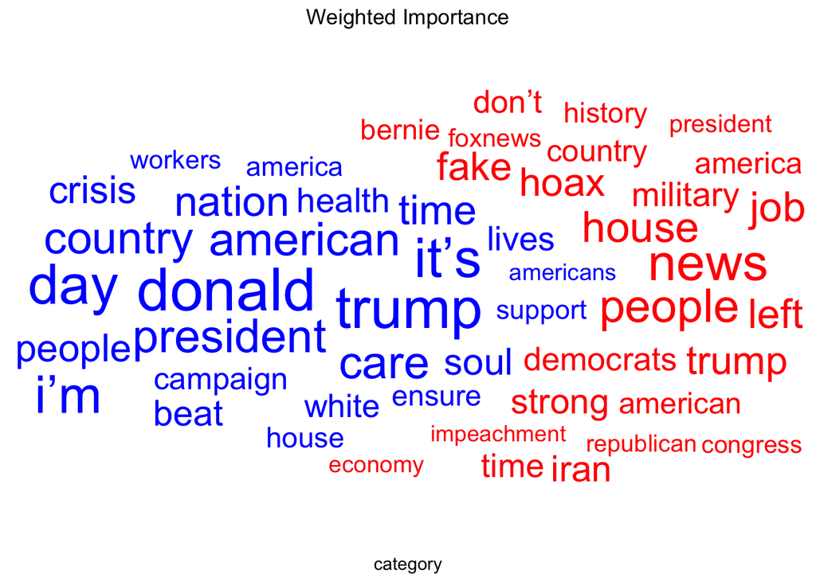

```r
set.seed(42)
ggplot(
  top_words_df2,
  aes(
    label = word, size = imp_val,
    x = category,
    color = category
  )
) +
  geom_text_wordcloud_area() +
  scale_size_area(max_size = 30) +
  scale_color_manual(values = c(
    "trump" = "red",
    "biden" = "blue"
  )) +
  scale_x_discrete(breaks = NULL) +
  theme_minimal() +
  labs(title = "Weighted Importance") +
  theme(plot.title = element_text(hjust = 0.5))
```

For our visualization, we wanted to use a method that was quick and easy to understand. Since we are dealing with different words and their frequencies, we decided to create a word cloud to compare the words most often used by both candidates in their tweets. We arranged the data by how many occurrences there were of each word and took the top 25 from each candidate. We then created a cloud of those words and that made words used more often larger and more prominent. We then made Biden’s words blue, and Trump’s red because of their political party affiliations.

Through the first visual, you can see that both candidates use terms associated with patriotism, such as America, American, and Americans (we decided not to group similar words by their “root” because of the time constraints of this project). They also address the individuals when they use terms like “people”. Words like “crisis” and “health” used by Biden show the impacts of the Covid-19 health crisis during the start of 2020 and Trump’s use of “military” and “Iran” are consistent with different political issues occurring abroad. Lastly, focus on both candidate’s upcoming presidential races are mentioned in words like “campaign” and “beat” used by Biden and “republican,” “democrats”, “impeachment”, “congress”, and “dems” by Trump. Overall, the models employed to explore the data are successful at pulling out key terms of importance and highlighting their similarities and overlaps as well as their differences.

We also decided to add a second model that directly incorporated our tuned model and use of PCA. We decided to create a new column to quantify word importance by the frequency weighted (multiplied) by the word_importance score we found earlier. It is important to note that because we used “ranger,” we only have an overall importance value, not a value for each candidate. Using the new value calculation method, our second model is sightly different. Some of the most important words for Trump were “people”, “news”, “democrats”, and “house”, while some of Biden’s most important words were “donald”, “president”, “american”, and “trump.” It is important to note that one of the words that appeared on Trump’s side of the graphic are the word “Trump”. If we were to use this data for further exploration with the new weights calculation, we should get rid of the term “Trump” so we don’t cause bias. Since it only occurs in our end graphic as a relatively small word, it is okay to leave it because this is just a short project exploration. In conclusion, these words align more closely with our set of important words, but the new graphic is still able to show similarities and differences between the candidates’ tweets.